# P6 TPG

Dhea Dewanti & Nur Khamidah

2023-09-18

# Analisis Profil

## Input Data

```r
dataset <- read.csv("C:\\Dhea\\S2 IPB\\Asisten Dosen\\STA1342\\Pertemuan 6\\Data.csv",sep = ";")
dataset
```

```
##    Informasi Similaritas Aritmetik Gambar    Kelompok
## 1          7           5         9      8 Tidak pikun
## 2          8           8         5      6 Tidak pikun
## 3         16          18        11      9 Tidak pikun
## 4          8           3         7      9 Tidak pikun
## 5          6           3        13      9 Tidak pikun
## 6         11           8        10     10 Tidak pikun
## 7         12           7         9      8 Tidak pikun
## 8          8          11         9      3 Tidak pikun
## 9         14          12        11      4 Tidak pikun
## 10        13          13        13      6 Tidak pikun
## 11        13           9         9      9 Tidak pikun
## 12        13          10        15      7 Tidak pikun
## 13        14          11        12      8 Tidak pikun
## 14        15          11        11     10 Tidak pikun
```

[output cut: 35 more lines]

## Mengaktifkan Library

```r
library(profileR)
```

## Visualisasi

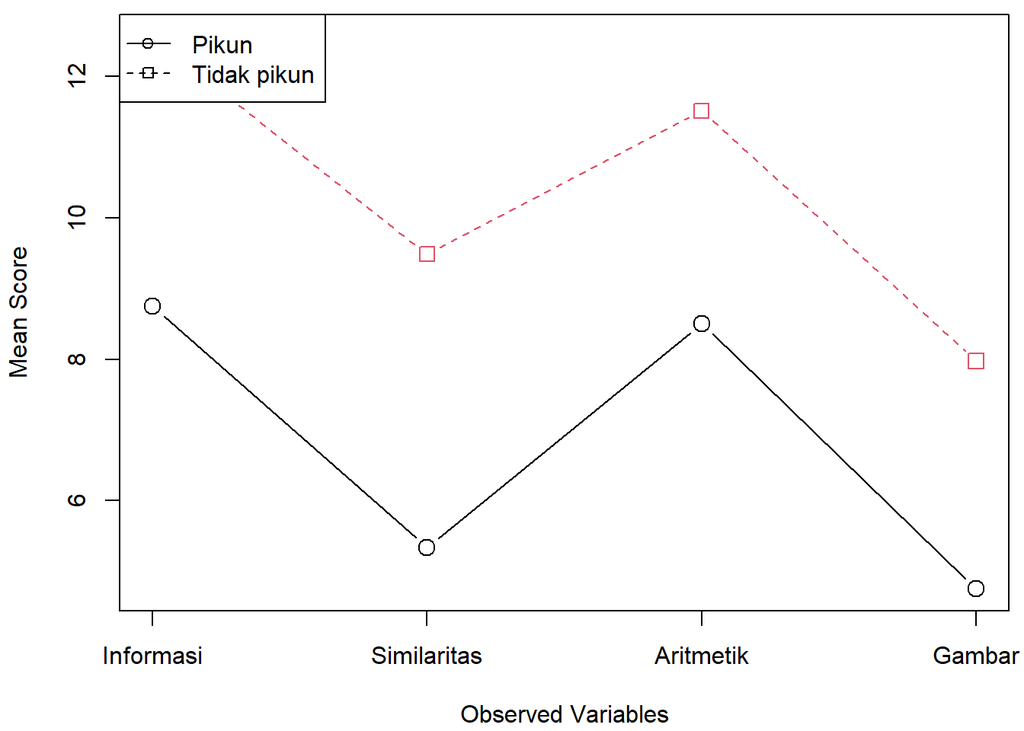

```r
mod <- pbg(data=dataset[,1:4], group=dataset[,5], original.name = TRUE, profile.plot = TRUE)
```

Berdasarkan grafik terlihat bahwa profil pikun sejajar dengan profil tidak pikun. Selain ini kedua profil tidak berhimpit. Dengan kata lain berdasarkan grafik peningkatan faktor pikun dan tidak pikun terhadap beberapa subtes sama. Sedangkan rata-rata hasil skor pikun berbeda dengan yang tidak pikun, di mana yang tidak pikun lebih tinggi.

```r
# rata-rata tiap perlakuan untuk dua kelompok
print(mod)
```

```
##
## Data Summary:
##                Pikun Tidak pikun
## Informasi   8.750000   12.567568
## Similaritas 5.333333    9.486486
## Aritmetik   8.500000   11.513514
## Gambar      4.750000    7.972973
```

```r
# semua perhitungan analisis profil
profil <- summary(mod)
```

```
## Call:
## pbg(data = dataset[, 1:4], group = dataset[, 5], original.names = TRUE,
##     profile.plot = TRUE)
##
## Hypothesis Tests:
## $`Ho: Profiles are parallel`
##   Multivariate.Test  Statistic  Approx.F num.df den.df   p.value
## 1             Wilks 0.97461349 0.3907166      3     45 0.7602428
## 2            Pillai 0.02538651 0.3907166      3     45 0.7602428
## 3  Hotelling-Lawley 0.02604778 0.3907166      3     45 0.7602428
## 4               Roy 0.02604778 0.3907166      3     45 0.7602428
##
## $`Ho: Profiles have equal levels`
##             Df Sum Sq Mean Sq F value   Pr(>F)
## group        1  114.3  114.31   17.44 0.000128 ***
## Residuals   47  308.1    6.56
## ---
## Signif. codes:  0 '***' 0.001 '**' 0.01 '*' 0.05 '.' 0.1 ' ' 1
##
## $`Ho: Profiles are flat`
##          F df1 df2      p-value
## 1 51.80163   3  45 1.223077e-14
```

## Uji Kesejajaran (Parallel Test)

$$H_{0}:C\mu_{1}=C\mu_{2}$$

$$H_{1}:C\mu_{1}\neq C\mu_{2}$$

```r
profil$`Ho: Profiles are parallel`
```

```
##   Multivariate.Test  Statistic  Approx.F num.df den.df   p.value
## 1             Wilks 0.97461349 0.3907166      3     45 0.7602428
## 2            Pillai 0.02538651 0.3907166      3     45 0.7602428
## 3  Hotelling-Lawley 0.02604778 0.3907166      3     45 0.7602428
## 4               Roy 0.02604778 0.3907166      3     45 0.7602428
```

Berdasarkan statistik di atas, diperoleh F hitung sebesar 0.39 dengan p-value sebesar 0.76 sehingga pada taraf signifikansi 5%, H0 gagal ditolak. Jadi, dapat disimpulkan bahwa profil antara kelompok Usia (Pikun dan Tidak Pikun) adalah sejajar.

## Uji Keberhimpitan

$$H_{0}:1'\mu_{1}=1'\mu_{2}$$

$$H_{1}:1'\mu_{1}\neq
1'\mu_{2}$$

```r
profil$`Ho: Profiles have equal levels`
```

```
##             Df Sum Sq Mean Sq F value   Pr(>F)
## group        1  114.3  114.31   17.44 0.000128 ***
## Residuals   47  308.1    6.56
## ---
## Signif. codes:  0 '***' 0.001 '**' 0.01 '*' 0.05 '.' 0.1 ' ' 1
```

Berdasarkan statistik di atas, diperoleh F hitung sebesar 17.44 dengan p-value 0.000128 sehingga pada taraf signifikansi 5%, H0 ditolak. Jadi, dapat disimpulkan bahwa profil antara kelompok Usia (Pikun dan Tidak Pikun) tidak berhimpit.

## Uji Kesamaan

```r
profil$`Ho: Profiles are flat`
```

```
##          F df1 df2      p-value
## 1 51.80163   3  45 1.223077e-14
```

Berdasarkan statistik di atas, diperoleh F hitung sebesar 51.80 dengan p-value 1.223077e-14 sehingga pada taraf signifikansi 5%, H0 ditolak. Jadi, dapat disimpulkan bahwa rata-rata untuk setiap sub tes pada lansia kelompok yang ada faktor kepikunan dan kelompok yang tidak ada faktor kepikunan menunjukkan konstanta yang berbeda.